# TP1_data_mining

```python
## Import packages
import pandas as pd
from pandas import set_option
import matplotlib.pyplot as plt
from matplotlib import cm
import seaborn as sns
import numpy as np
from sklearn.cluster import KMeans
import warnings
warnings.filterwarnings('ignore')
from sklearn.neighbors import LocalOutlierFactor
from sklearn.model_selection import train_test_split
from sklearn.preprocessing import StandardScaler
from sklearn.cluster import KMeans
from sklearn import preprocessing
import pylab
import scipy.stats as stats
from sklearn.model_selection import StratifiedKFold, KFold
from sklearn.metrics.cluster import adjusted_rand_score
```

## Loading data

```python
# Load data from
df=pd.read_csv("breast-cancer-wisconsin.data",delimiter=',',header = None)
```

```python
df
```

|  | 0 | 1 | 2 | 3 | 4 | 5 | 6 | 7 | 8 | 9 | 10 |
| --- | --- | --- | --- | --- | --- | --- | --- | --- | --- | --- | --- |
| 0 | 1000025 | 5 | 1 | 1 | 1 | 2 | 1 | 3 | 1 | 1 | 2 |
| 1 | 1002945 | 5 | 4 | 4 | 5 | 7 | 10 | 3 | 2 | 1 | 2 |
| 2 | 1015425 | 3 | 1 | 1 | 1 | 2 | 2 | 3 | 1 | 1 | 2 |
| 3 | 1016277 | 6 | 8 | 8 | 1 | 3 | 4 | 3 | 7 | 1 | 2 |
| 4 | 1017023 | 4 | 1 | 1 | 3 | 2 | 1 | 3 | 1 | 1 | 2 |
| ... | ... | ... | ... | ... | ... | ... | ... | ... | ... | ... | ... |
| 694 | 776715 | 3 | 1 | 1 | 1 | 3 | 2 | 1 | 1 | 1 | 2 |
| 695 | 841769 | 2 | 1 | 1 | 1 | 2 | 1 | 1 | 1 | 1 | 2 |
| 696 | 888820 | 5 | 10 | 10 | 3 | 7 | 3 | 8 | 10 | 2 | 4 |
| 697 | 897471 | 4 | 8 | 6 | 4 | 3 | 4 | 10 | 6 | 1 | 4 |
| 698 | 897471 | 4 | 8 | 8 | 5 | 4 | 5 | 10 | 4 | 1 | 4 |

699 rows × 11 columns

```python
columns = ['id_number','Clump_Thickness','Uniformity_of_Cell_Size',' Uniformity_of_Cell_Shape','Marginal_Adhesion', 'Single_Epithelial_Cell_Size', 'Bare_Nuclei','Bland_Chromatin','Normal_Nucleoli','Mitoses','Class']

df.set_axis(columns, axis='columns',inplace=True)
df.head()
```

|  | id_number | Clump_Thickness | Uniformity_of_Cell_Size | Uniformity_of_Cell_Shape | Marginal_Adhesion | Single_Epithelial_Cell_Size | Bare_Nuclei | Bland_Chromatin | Normal_Nucleoli | Mitoses | Class |
| --- | --- | --- | --- | --- | --- | --- | --- | --- | --- | --- | --- |
| 0 | 1000025 | 5 | 1 | 1 | 1 | 2 | 1 | 3 | 1 | 1 | 2 |
| 1 | 1002945 | 5 | 4 | 4 | 5 | 7 | 10 | 3 | 2 | 1 | 2 |
| 2 | 1015425 | 3 | 1 | 1 | 1 | 2 | 2 | 3 | 1 | 1 | 2 |
| 3 | 1016277 | 6 | 8 | 8 | 1 | 3 | 4 | 3 | 7 | 1 | 2 |
| 4 | 1017023 | 4 | 1 | 1 | 3 | 2 | 1 | 3 | 1 | 1 | 2 |

## Ged rid of meaningless columns

```python
#Since we don't need the id column
df.drop("id_number", axis=1, inplace=True)
columns = ['Clump_Thickness','Uniformity_of_Cell_Size',' Uniformity_of_Cell_Shape','Marginal_Adhesion', 'Single_Epithelial_Cell_Size', 'Bare_Nuclei','Bland_Chromatin','Normal_Nucleoli','Mitoses','Class']
df.head()
```

|  | Clump_Thickness | Uniformity_of_Cell_Size | Uniformity_of_Cell_Shape | Marginal_Adhesion | Single_Epithelial_Cell_Size | Bare_Nuclei | Bland_Chromatin | Normal_Nucleoli | Mitoses | Class |
| --- | --- | --- | --- | --- | --- | --- | --- | --- | --- | --- |
| 0 | 5 | 1 | 1 | 1 | 2 | 1 | 3 | 1 | 1 | 2 |
| 1 | 5 | 4 | 4 | 5 | 7 | 10 | 3 | 2 | 1 | 2 |
| 2 | 3 | 1 | 1 | 1 | 2 | 2 | 3 | 1 | 1 | 2 |
| 3 | 6 | 8 | 8 | 1 | 3 | 4 | 3 | 7 | 1 | 2 |
| 4 | 4 | 1 | 1 | 3 | 2 | 1 | 3 | 1 | 1 | 2 |

## Missing values

```python
df.isna().sum()
```

```
Clump_Thickness                0
Uniformity_of_Cell_Size        0
 Uniformity_of_Cell_Shape      0
Marginal_Adhesion              0
Single_Epithelial_Cell_Size    0
Bare_Nuclei                    0
Bland_Chromatin                0
Normal_Nucleoli                0
Mitoses                        0
Class                          0
dtype: int64
```

```python
num_df = (df.drop(columns, axis=1).join(df[columns].apply(pd.to_numeric, errors='coerce')))
```

```python
num_df.isna().sum()
```

```
Clump_Thickness                 0
Uniformity_of_Cell_Size         0
 Uniformity_of_Cell_Shape       0
Marginal_Adhesion               0
Single_Epithelial_Cell_Size     0
Bare_Nuclei                    16
Bland_Chromatin                 0
Normal_Nucleoli                 0
Mitoses                         0
Class                           0
dtype: int64
```

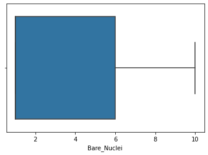

```python
import seaborn as sns
# Box plot
sns.boxplot(num_df.Bare_Nuclei)
```

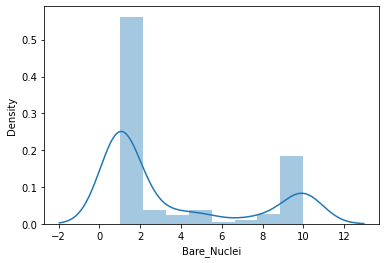

```python
# Distribution plot
sns.distplot(num_df.Bare_Nuclei)
```

```python
# Remplacer en utilisant la médiane
median = num_df['Bare_Nuclei'].median()
num_df['Bare_Nuclei'].fillna(median, inplace=True)
```

```python
num_df.isna().sum()
```

```
Clump_Thickness                0
Uniformity_of_Cell_Size        0
 Uniformity_of_Cell_Shape      0
Marginal_Adhesion              0
Single_Epithelial_Cell_Size    0
Bare_Nuclei                    0
Bland_Chromatin                0
Normal_Nucleoli                0
Mitoses                        0
Class                          0
dtype: int64
```

## 1- Understanding the data via statistical summaries

```python
median = num_df.median()
median
```

```
Clump_Thickness                4.0
Uniformity_of_Cell_Size        1.0
 Uniformity_of_Cell_Shape      1.0
Marginal_Adhesion              1.0
Single_Epithelial_Cell_Size    2.0
Bare_Nuclei                    1.0
Bland_Chromatin                3.0
Normal_Nucleoli                1.0
Mitoses                        1.0
Class                          2.0
dtype: float64
```

```python
mean= num_df.mean()
mean
```

```
Clump_Thickness                4.417740
Uniformity_of_Cell_Size        3.134478
 Uniformity_of_Cell_Shape      3.207439
Marginal_Adhesion              2.806867
Single_Epithelial_Cell_Size    3.216023
Bare_Nuclei                    3.486409
Bland_Chromatin                3.437768
Normal_Nucleoli                2.866953
Mitoses                        1.589413
Class                          2.689557
dtype: float64
```

```python
#Summary statistics:

num_df.describe().T
```

|  | count | mean | std | min | 25% | 50% | 75% | max |
| --- | --- | --- | --- | --- | --- | --- | --- | --- |
| Clump_Thickness | 699.0 | 4.417740 | 2.815741 | 1.0 | 2.0 | 4.0 | 6.0 | 10.0 |
| Uniformity_of_Cell_Size | 699.0 | 3.134478 | 3.051459 | 1.0 | 1.0 | 1.0 | 5.0 | 10.0 |
| Uniformity_of_Cell_Shape | 699.0 | 3.207439 | 2.971913 | 1.0 | 1.0 | 1.0 | 5.0 | 10.0 |
| Marginal_Adhesion | 699.0 | 2.806867 | 2.855379 | 1.0 | 1.0 | 1.0 | 4.0 | 10.0 |
| Single_Epithelial_Cell_Size | 699.0 | 3.216023 | 2.214300 | 1.0 | 2.0 | 2.0 | 4.0 | 10.0 |
| Bare_Nuclei | 699.0 | 3.486409 | 3.621929 | 1.0 | 1.0 | 1.0 | 5.0 | 10.0 |
| Bland_Chromatin | 699.0 | 3.437768 | 2.438364 | 1.0 | 2.0 | 3.0 | 5.0 | 10.0 |
| Normal_Nucleoli | 699.0 | 2.866953 | 3.053634 | 1.0 | 1.0 | 1.0 | 4.0 | 10.0 |
| Mitoses | 699.0 | 1.589413 | 1.715078 | 1.0 | 1.0 | 1.0 | 1.0 | 10.0 |
| Class | 699.0 | 2.689557 | 0.951273 | 2.0 | 2.0 | 2.0 | 4.0 | 4.0 |

## 2- Data distribution

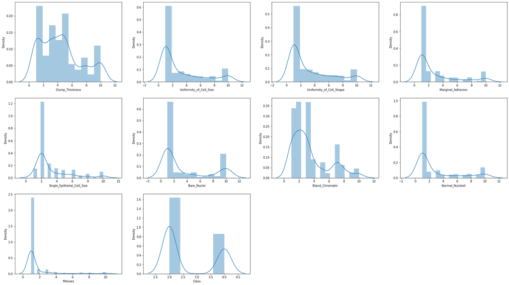

```python
plt.figure(figsize= (30,29))
pos = 1
for feature in num_df.columns:
    plt.subplot(5, 4, pos)
    if feature in df.columns:
         sns.distplot(num_df[feature], kde= True )
    else:
        sns.countplot(num_df[feature], palette= 'Blues')

    pos += 1
```

```python
#skewness in the data
num_df.skew()
```

```
Clump_Thickness                0.592859
Uniformity_of_Cell_Size        1.233137
 Uniformity_of_Cell_Shape      1.161859
Marginal_Adhesion              1.524468
Single_Epithelial_Cell_Size    1.712172
Bare_Nuclei                    1.025347
Bland_Chromatin                1.099969
Normal_Nucleoli                1.422261
Mitoses                        3.560658
Class                          0.654564
dtype: float64
```

```python
#function to return plots for the feature
def normality(data,feature):
    plt.figure(figsize=(10,5))
    plt.subplot(1,2,1)
    sns.kdeplot(data[feature])
    plt.subplot(1,2,2)
    stats.probplot(data[feature],plot=pylab)
    plt.show()
```

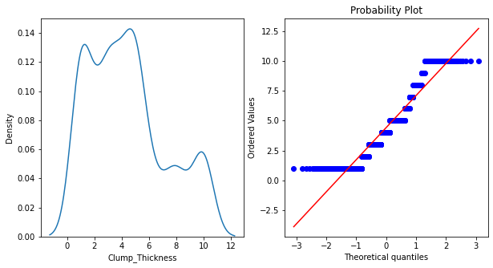

```python
normality(num_df,'Clump_Thickness')
```

```python
#performing logarithmic transformation on the feature
num_df['Clump_Thickness']=np.log(num_df['Clump_Thickness'])
```

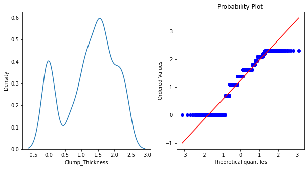

```python
normality(num_df,'Clump_Thickness')
```

```python
#performing logarithmic transformation on the feature
#num_df.Clump_Thickness=np.log(num_df.Clump_Thickness)
num_df[' Uniformity_of_Cell_Shape']=np.log(num_df[' Uniformity_of_Cell_Shape'])
num_df.Bland_Chromatin=np.log(num_df.Bland_Chromatin)

num_df.Uniformity_of_Cell_Size=np.log(num_df.Uniformity_of_Cell_Size)
num_df.Marginal_Adhesion =np.log(num_df.Marginal_Adhesion )
num_df.Single_Epithelial_Cell_Size=np.log(num_df.Single_Epithelial_Cell_Size)
num_df.Bare_Nuclei =np.log(num_df.Bare_Nuclei )
num_df.Normal_Nucleoli=np.log(num_df.Normal_Nucleoli)
num_df.Mitoses=np.log(num_df.Mitoses)
```

```python
#skewness in the data
num_df.skew()
```

```
Clump_Thickness               -0.449422
Uniformity_of_Cell_Size        0.659280
 Uniformity_of_Cell_Shape      0.537375
Marginal_Adhesion              0.878514
Single_Epithelial_Cell_Size    0.711588
Bare_Nuclei                    0.721701
Bland_Chromatin                0.102300
Normal_Nucleoli                0.963659
Mitoses                        2.462636
Class                          0.654564
dtype: float64
```

## 3- Blanced Classes

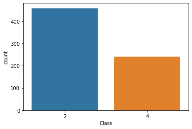

```python
#la densité de notre variable cible
sns.countplot(num_df["Class"])
```

## 4- Outliers detection

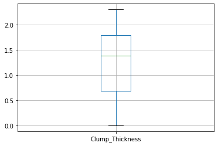

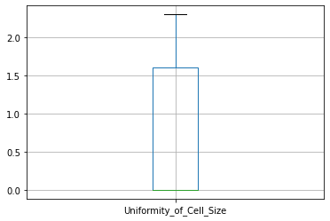

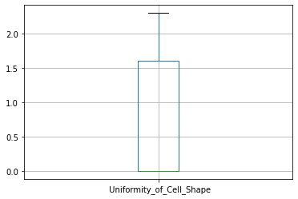

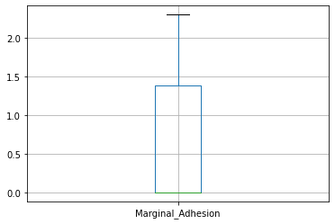

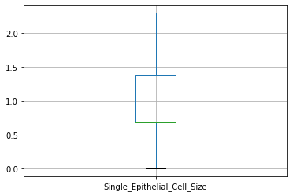

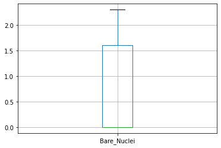

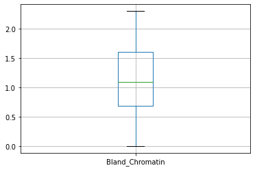

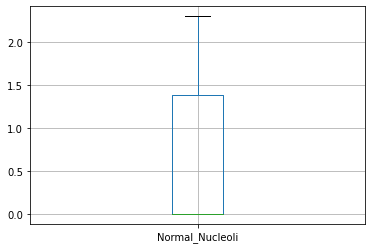

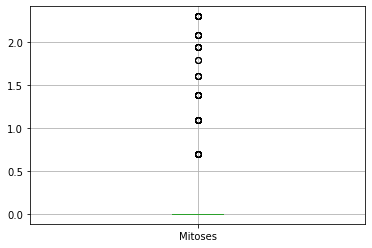

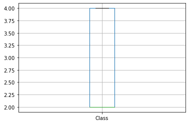

```python
for column in num_df:
    plt.figure()
    num_df.boxplot([column])
```

```python
#from scipy.stats.mstats import winsorize
#WinsorizedArray2 = winsorize(num_df.Clump_Thickness,(0.01,0.02))
# In this case, the lower 10% values of
# the data will have their values set equal to the value of the data point at
#the 10th percentile.

#plt.boxplot(WinsorizedArray2)
#plt.show()

#WinsorizedArray2Mean = np.mean(WinsorizedArray2)
#WinsorizedArray2Mean
```

```python
num_df.dtypes
```

```
Clump_Thickness                float64
Uniformity_of_Cell_Size        float64
 Uniformity_of_Cell_Shape      float64
Marginal_Adhesion              float64
Single_Epithelial_Cell_Size    float64
Bare_Nuclei                    float64
Bland_Chromatin                float64
Normal_Nucleoli                float64
Mitoses                        float64
Class                            int64
dtype: object
```

## 5- La corrélation des variables

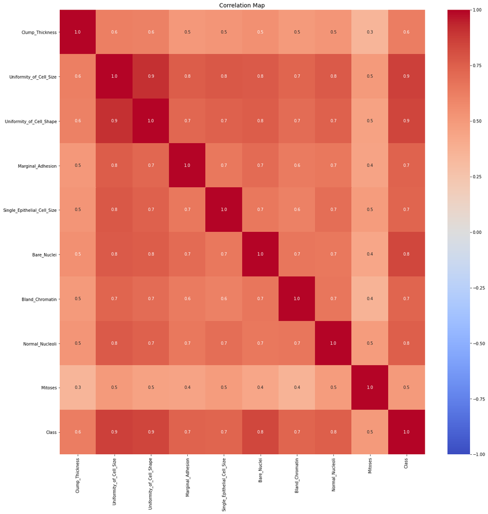

```python
f, ax = plt.subplots(figsize = (20,20))
sns.heatmap(num_df.corr(), annot=True, fmt='.1f',
            ax=ax, cmap='coolwarm', vmin=-1, vmax=1)
plt.xticks(rotation=90)
plt.yticks(rotation=0)
plt.title('Correlation Map', size=14);
```

mis à part la diagonale on peut voir les variables qui ont un coéfficient de corrélation élevé :

-Ansi peut aussi faire des ensemles de variables corrélées (on peut par exemple dire qu'on considède que 2 variables ayant un coeff supérieur à 0.8 sont corrélées) , et décider d'en prendre une seule dans chaque ensemble pour la suite de l'analyse .

-En d'autres termes, le fait qu'une des caractéristiques que nous comparons ait une valeur élevée entraîne une valeur élevée pour l'autre. L'analyse que nous ferons de cette manière ne donnera pas des résultats exactement corrects. En effet, lorsque la valeur de l'une des caractéristiques à forte corrélation augmente, l'autre augmente également.

## 6- Clustring : KMeans

### K choice (Méthode Elbow)

On utilise la méthode Elbow qui est l'un des moyens pour trouver le nombre optimal de clusters. Cette méthode utilise le concept de la valeur WCSS. WCSS (Within Cluster Sum of Squares), qui définit les variations totales au sein d'un cluster.

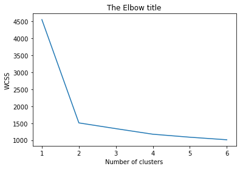

```python
wcss=[]
for i in range(1,7):
    kmeans = KMeans(i)
    kmeans.fit(num_df)
    wcss_iter = kmeans.inertia_
    wcss.append(wcss_iter)

number_clusters = range(1,7)
plt.plot(number_clusters,wcss)
plt.title('The Elbow title')
plt.xlabel('Number of clusters')
plt.ylabel('WCSS')
```

Commentaire:Le point de courbure est considéré comme la meilleure valeur de K. Ainsi, la valeur optimale de K est 2.Donc l'algorithme retrouve bien le bon K .

```python
X_final = num_df.iloc[:, 1:8]
y_final = num_df.iloc[:,9]
```

```python
X_final=X_final.reset_index(drop=True)
```

```python
y_final =y_final.reset_index(drop=True)
```

```python
X_final
```

|  | Uniformity_of_Cell_Size | Uniformity_of_Cell_Shape | Marginal_Adhesion | Single_Epithelial_Cell_Size | Bare_Nuclei | Bland_Chromatin | Normal_Nucleoli |
| --- | --- | --- | --- | --- | --- | --- | --- |
| 0 | 0.000000 | 0.000000 | 0.000000 | 0.693147 | 0.000000 | 1.098612 | 0.000000 |
| 1 | 1.386294 | 1.386294 | 1.609438 | 1.945910 | 2.302585 | 1.098612 | 0.693147 |
| 2 | 0.000000 | 0.000000 | 0.000000 | 0.693147 | 0.693147 | 1.098612 | 0.000000 |
| 3 | 2.079442 | 2.079442 | 0.000000 | 1.098612 | 1.386294 | 1.098612 | 1.945910 |
| 4 | 0.000000 | 0.000000 | 1.098612 | 0.693147 | 0.000000 | 1.098612 | 0.000000 |
| ... | ... | ... | ... | ... | ... | ... | ... |
| 694 | 0.000000 | 0.000000 | 0.000000 | 1.098612 | 0.693147 | 0.000000 | 0.000000 |
| 695 | 0.000000 | 0.000000 | 0.000000 | 0.693147 | 0.000000 | 0.000000 | 0.000000 |
| 696 | 2.302585 | 2.302585 | 1.098612 | 1.945910 | 1.098612 | 2.079442 | 2.302585 |
| 697 | 2.079442 | 1.791759 | 1.386294 | 1.098612 | 1.386294 | 2.302585 | 1.791759 |
| 698 | 2.079442 | 2.079442 | 1.609438 | 1.386294 | 1.609438 | 2.302585 | 1.386294 |

699 rows × 7 columns

```python
y_final
```

```
0      2
1      2
2      2
3      2
4      2
      ..
694    2
695    2
696    4
697    4
698    4
Name: Class, Length: 699, dtype: int64
```

```python
#SPLIT
X_train, X_test, y_train, y_test = train_test_split(X_final,y_final, train_size=0.8, random_state = 1,stratify=y_final)
```

```python
kmeans=KMeans(n_clusters=2)
```

```python
kmeans.fit(X_train,y_train)
```

```
KMeans(n_clusters=2)
```

```python
y_pred=kmeans.predict(X_test)
```

```python
adjusted_rand_score(y_test,y_pred)
```

```
0.7557757024833293
```

## 7- Agglomerative clustering

```python
from sklearn.cluster import AgglomerativeClustering
cluster = AgglomerativeClustering(n_clusters=2, affinity='euclidean', linkage='ward')
```

```python
cluster.fit(X_train,y_train)
```

```
AgglomerativeClustering()
```

```python
y_pred2=cluster.fit_predict(X_test)
```

```python
adjusted_rand_score(y_test,y_pred2)
```

```
0.7304895667992124
```